# Project: Investigate a Dataset - TMDb Movie Data: What Is Associated With Movie Success?

- Introduction
- Data Wrangling
- Exploratory Data Analysis
- Standout: Dramatic Arcs of the Dementia-Themed Films
- Conclusions

## Introduction

### Dataset Description

This project analyzes the **TMDb movie dataset**, which contains information on **10,866 movies** collected from [The Movie Database (TMDb)](https://www.themoviedb.org/). The data was cleaned by Udacity from the original [Kaggle release](https://www.kaggle.com/tmdb/tmdb-movie-metadata). It is a single table with **21 columns**:

| Column | Description |
| --- | --- |
| `id` | TMDb identifier for the movie |
| `imdb_id` | IMDb identifier (e.g. `tt0369610`) |
| `popularity` | TMDb popularity score (relative, unbounded) |
| `budget` | Production budget in nominal US dollars |
| `revenue` | Box-office revenue in nominal US dollars |
| `original_title` | Title of the movie |
| `cast` | Lead actors, pipe-separated (`\\|`), capped at five names |
| `homepage` | Official website URL |
| `director` | Director(s) of the movie |
| `tagline` | Marketing tagline |
| `keywords` | Plot keywords, pipe-separated (`\\|`) |
| `overview` | Short plot summary |
| `runtime` | Length of the movie in minutes |
| `genres` | Genres, pipe-separated (`\\|`) |
| `production_companies` | Production companies, pipe-separated (`\\|`) |
| `release_date` | Release date (stored as text) |
| `vote_count` | Number of user votes |
| `vote_average` | Average user rating (0–10) |
| `release_year` | Year of release (integer) |
| `budget_adj` | Budget in inflation-adjusted 2010 US dollars |
| `revenue_adj` | Revenue in inflation-adjusted 2010 US dollars |

A few characteristics are important for the analysis. Four columns (`cast`, `keywords`, `genres`, `production_companies`) store **multiple pipe-separated values** in a single field. The `budget_adj` and `revenue_adj` columns express money in **2010 dollars**, which makes financial comparisons across decades fair, so they are preferred over the raw `budget` / `revenue` columns. Finally, several numeric columns use `0` to encode missing data (notably `budget`, `revenue`, and `runtime`), which is addressed in the Data Wrangling section.

### Question(s) for Analysis

This report investigates what is associated with a movie's **success**, using two complementary outcome measures as the primary **dependent variables**:

- **`revenue_adj`** — box-office revenue in inflation-adjusted 2010 US dollars, and
- **`vote_average`** — the average TMDb user rating.

These outcomes are explored against several **independent variables** — listed cast size, release year, actor prolificness, production budget, and genre — through the following four questions:

1. **Cast size over time and success:** How has the number of *listed* cast members changed across release years, and is listed cast size related to a movie's revenue? *(independent variables: listed cast size, `release_year`)*
2. **Small-cast performance:** Do movies with small listed casts (1–3 names) perform differently from full 5-listed-cast movies on revenue, rating, and popularity? *(independent variable: listed cast-size group)*
3. **Veteran stars:** Do movies featuring a prolific/veteran actor — measured by the number of films an actor appears in within this dataset — earn more or score higher than movies without one? *(independent variables: presence of a prolific actor, `budget_adj`)*
4. **Genre landscape:** Which genres are associated with higher ratings versus higher revenue, and where do niche illness/"dementia" themes sit within that landscape? *(independent variable: `genres`)*

The analysis uses a mix of single-variable (1d) and multiple-variable (2d) views, and each question carries a clearly stated limitation (for example, the `cast` column is capped at five names, and film count is only a proxy for an actor's seniority).

```python
# Use this cell to set up import statements for all of the packages that you
#   plan to use.
import numpy as np
import pandas as pd
import matplotlib.pyplot as plt
import seaborn as sns

# Magic word so that visualizations are plotted inline with the notebook.
%matplotlib inline

# Set a consistent style for all plots in the report.
sns.set_style('darkgrid')
```

## Data Wrangling

### General Properties

```python
# Load the TMDb movie dataset into a DataFrame.
df = pd.read_csv('Database_TMDb_movie_data/tmdb-movies.csv')

# Look at the size of the dataframe (rows, columns) and the first few rows.
print('Shape (rows, columns):', df.shape)
df.head()
```

```
Shape (rows, columns): (10866, 21)
```

|  | id | imdb_id | popularity | budget | revenue | original_title | cast | homepage | director | tagline | ... | overview | runtime | genres | production_companies | release_date | vote_count | vote_average | release_year | budget_adj | revenue_adj |
| --- | --- | --- | --- | --- | --- | --- | --- | --- | --- | --- | --- | --- | --- | --- | --- | --- | --- | --- | --- | --- | --- |
| 0 | 135397 | tt0369610 | 32.985763 | 150000000 | 1513528810 | Jurassic World | Chris Pratt\|Bryce Dallas Howard\|Irrfan Khan\|Vi... | http://www.jurassicworld.com/ | Colin Trevorrow | The park is open. | ... | Twenty-two years after the events of Jurassic ... | 124 | Action\|Adventure\|Science Fiction\|Thriller | Universal Studios\|Amblin Entertainment\|Legenda... | 6/9/15 | 5562 | 6.5 | 2015 | 1.379999e+08 | 1.392446e+09 |
| 1 | 76341 | tt1392190 | 28.419936 | 150000000 | 378436354 | Mad Max: Fury Road | Tom Hardy\|Charlize Theron\|Hugh Keays-Byrne\|Nic... | http://www.madmaxmovie.com/ | George Miller | What a Lovely Day. | ... | An apocalyptic story set in the furthest reach... | 120 | Action\|Adventure\|Science Fiction\|Thriller | Village Roadshow Pictures\|Kennedy Miller Produ... | 5/13/15 | 6185 | 7.1 | 2015 | 1.379999e+08 | 3.481613e+08 |
| 2 | 262500 | tt2908446 | 13.112507 | 110000000 | 295238201 | Insurgent | Shailene Woodley\|Theo James\|Kate Winslet\|Ansel... | http://www.thedivergentseries.movie/#insurgent | Robert Schwentke | One Choice Can Destroy You | ... | Beatrice Prior must confront her inner demons ... | 119 | Adventure\|Science Fiction\|Thriller | Summit Entertainment\|Mandeville Films\|Red Wago... | 3/18/15 | 2480 | 6.3 | 2015 | 1.012000e+08 | 2.716190e+08 |
| 3 | 140607 | tt2488496 | 11.173104 | 200000000 | 2068178225 | Star Wars: The Force Awakens | Harrison Ford\|Mark Hamill\|Carrie Fisher\|Adam D... | http://www.starwars.com/films/star-wars-episod... | J.J. Abrams | Every generation has a story. | ... | Thirty years after defeating the Galactic Empi... | 136 | Action\|Adventure\|Science Fiction\|Fantasy | Lucasfilm\|Truenorth Productions\|Bad Robot | 12/15/15 | 5292 | 7.5 | 2015 | 1.839999e+08 | 1.902723e+09 |
| 4 | 168259 | tt2820852 | 9.335014 | 190000000 | 1506249360 | Furious 7 | Vin Diesel\|Paul Walker\|Jason Statham\|Michelle ... | http://www.furious7.com/ | James Wan | Vengeance Hits Home | ... | Deckard Shaw seeks revenge against Dominic Tor... | 137 | Action\|Crime\|Thriller | Universal Pictures\|Original Film\|Media Rights ... | 4/1/15 | 2947 | 7.3 | 2015 | 1.747999e+08 | 1.385749e+09 |

5 rows × 21 columns

```python
# Inspect column data types and non-null counts.
df.info()
```

```
<class 'pandas.DataFrame'>
RangeIndex: 10866 entries, 0 to 10865
Data columns (total 21 columns):
 #   Column                Non-Null Count  Dtype
---  ------                --------------  -----
 0   id                    10866 non-null  int64
 1   imdb_id               10856 non-null  str
 2   popularity            10866 non-null  float64
 3   budget                10866 non-null  int64
 4   revenue               10866 non-null  int64
 5   original_title        10866 non-null  str
 6   cast                  10790 non-null  str
 7   homepage              2936 non-null   str
 8   director              10822 non-null  str
 9   tagline               8042 non-null   str
 10  keywords              9373 non-null   str
 11  overview              10862 non-null  str
 12  runtime               10866 non-null  int64
 13  genres                10843 non-null  str
 14  production_companies  9836 non-null   str
 15  release_date          10866 non-null  str
 16  vote_count            10866 non-null  int64
 17  vote_average          10866 non-null  float64
 18  release_year          10866 non-null  int64
 19  budget_adj            10866 non-null  float64
 20  revenue_adj           10866 non-null  float64
dtypes: float64(4), int64(6), str(11)
memory usage: 1.7 MB
```

**Observation — structure and data types**

The dataset has **10,866 rows and 21 columns**: 6 integer, 4 float, and 11 text (`str`) columns. A few things to note for cleaning:

- `release_date` is stored as text rather than a datetime, but `release_year` is already available as an integer for year-based analysis.
- Columns such as `cast`, `genres`, `keywords`, and `production_companies` store multiple pipe-separated (`|`) values in a single field.
- The `id` and `imdb_id` columns are identifiers, not measurements.

```python
# Summary statistics for the numeric columns.
df.describe()
```

|  | id | popularity | budget | revenue | runtime | vote_count | vote_average | release_year | budget_adj | revenue_adj |
| --- | --- | --- | --- | --- | --- | --- | --- | --- | --- | --- |
| count | 10866.000000 | 10866.000000 | 1.086600e+04 | 1.086600e+04 | 10866.000000 | 10866.000000 | 10866.000000 | 10866.000000 | 1.086600e+04 | 1.086600e+04 |
| mean | 66064.177434 | 0.646441 | 1.462570e+07 | 3.982332e+07 | 102.070863 | 217.389748 | 5.974922 | 2001.322658 | 1.755104e+07 | 5.136436e+07 |
| std | 92130.136561 | 1.000185 | 3.091321e+07 | 1.170035e+08 | 31.381405 | 575.619058 | 0.935142 | 12.812941 | 3.430616e+07 | 1.446325e+08 |
| min | 5.000000 | 0.000065 | 0.000000e+00 | 0.000000e+00 | 0.000000 | 10.000000 | 1.500000 | 1960.000000 | 0.000000e+00 | 0.000000e+00 |
| 25% | 10596.250000 | 0.207583 | 0.000000e+00 | 0.000000e+00 | 90.000000 | 17.000000 | 5.400000 | 1995.000000 | 0.000000e+00 | 0.000000e+00 |
| 50% | 20669.000000 | 0.383856 | 0.000000e+00 | 0.000000e+00 | 99.000000 | 38.000000 | 6.000000 | 2006.000000 | 0.000000e+00 | 0.000000e+00 |
| 75% | 75610.000000 | 0.713817 | 1.500000e+07 | 2.400000e+07 | 111.000000 | 145.750000 | 6.600000 | 2011.000000 | 2.085325e+07 | 3.369710e+07 |
| max | 417859.000000 | 32.985763 | 4.250000e+08 | 2.781506e+09 | 900.000000 | 9767.000000 | 9.200000 | 2015.000000 | 4.250000e+08 | 2.827124e+09 |

**Observation — summary statistics**

A few numeric columns contain implausible zero values that almost certainly represent missing data recorded as `0` rather than true measurements:

- `budget` / `budget_adj`: **5,696** movies have a value of 0.
- `revenue` / `revenue_adj`: **6,016** movies have a value of 0.
- `runtime`: **31** movies have a runtime of 0.

`release_year` ranges from **1960 to 2015**. These zero-as-missing values will need to be handled before any analysis involving budget, revenue, or runtime.

```python
# Count missing values per column (show only columns that have any).
missing = df.isnull().sum()
missing[missing > 0].sort_values(ascending=False)
```

```
homepage                7930
tagline                 2824
keywords                1493
production_companies    1030
cast                      76
director                  44
genres                    23
imdb_id                   10
overview                   4
dtype: int64
```

**Observation — missing values**

Several columns contain missing values. The text/descriptive columns are the most affected: `homepage` (7,930 missing), `tagline` (2,824), `keywords` (1,493), and `production_companies` (1,030). A smaller number are missing in `cast` (76), `director` (44), `genres` (23), `imdb_id` (10), and `overview` (4).

None of the core numeric columns used for analysis (`popularity`, `budget_adj`, `revenue_adj`, `runtime`, `vote_average`, `vote_count`, `release_year`) have `NaN` values.

```python
# Check for fully duplicated rows.
df.duplicated().sum()
```

```
np.int64(1)
```

**Observation — duplicates**

There is exactly **1 fully duplicated row** in the dataset. It will be removed during the Data Cleaning step.

### Data Cleaning

Based on the inspection above, the cleaning plan is:

1. **Remove the single fully duplicated row.**
2. **Treat zeros as missing.** `budget`, `revenue`, `budget_adj`, `revenue_adj`, and `runtime` use `0` to encode missing measurements. We convert those zeros to `NaN` so that financial/runtime analyses can drop them per question rather than deleting whole rows up front (which would needlessly discard movies that still have valid ratings, genres, and cast information).
3. **Leave descriptive text columns as-is.** Missing values in `homepage`, `tagline`, `keywords`, etc. are not central to the questions, so no rows are dropped for them.

The steps are implemented as small, **reusable functions** so the same logic can be applied to other datasets that share these common problems (duplicate rows and zero-coded missing values).

```python
# --- Reusable, dataset-agnostic data-cleaning helpers ---
# These functions take any DataFrame so the same cleaning logic can be reused on
# other datasets, not just this one.

def drop_full_duplicates(data, verbose=True):
    """Return a copy of `data` with exact duplicate rows removed and the index reset."""
    n_before = len(data)
    cleaned = data.drop_duplicates().reset_index(drop=True)
    if verbose:
        print(f'Removed {n_before - len(cleaned)} duplicate row(s); {len(cleaned)} rows remain.')
    return cleaned


def zeros_to_nan(data, columns, verbose=True):
    """Return a copy of `data` where 0 values in `columns` are treated as missing (NaN).

    Useful whenever a dataset encodes missing measurements as 0 instead of NaN.
    """
    cleaned = data.copy()
    for col in columns:
        n_zeros = int((cleaned[col] == 0).sum())
        cleaned[col] = cleaned[col].replace(0, np.nan)
        if verbose:
            print(f'{col}: converted {n_zeros} zero value(s) to NaN.')
    return cleaned
```

```python
# Apply the reusable cleaning helpers to build the analysis DataFrame `df_clean`.
# Columns where 0 means "missing" rather than a true measurement.
zero_as_missing = ['budget', 'revenue', 'budget_adj', 'revenue_adj', 'runtime']

df_clean = drop_full_duplicates(df)
df_clean = zeros_to_nan(df_clean, zero_as_missing)
print('Cleaned shape (rows, columns):', df_clean.shape)
```

```
Removed 1 duplicate row(s); 10865 rows remain.
budget: converted 5696 zero value(s) to NaN.
revenue: converted 6016 zero value(s) to NaN.
budget_adj: converted 5696 zero value(s) to NaN.
revenue_adj: converted 6016 zero value(s) to NaN.
runtime: converted 31 zero value(s) to NaN.
Cleaned shape (rows, columns): (10865, 21)
```

```python
# Confirm the cleaning worked: no duplicates remain and zeros became NaN.
print('Duplicate rows remaining:', df_clean.duplicated().sum())
df_clean[zero_as_missing].isnull().sum()
```

```
Duplicate rows remaining: 0
```

```
budget         5696
revenue        6016
budget_adj     5696
revenue_adj    6016
runtime          31
dtype: int64
```

**Result of cleaning**

The cleaned DataFrame `df_clean` has **10,865 rows** (the one duplicate removed). The zero-as-missing conversion turned `budget`/`budget_adj` into 5,696 `NaN`s, `revenue`/`revenue_adj` into 6,016 `NaN`s, and `runtime` into 31 `NaN`s. No rows were dropped for these, so movies still contribute to rating-, genre-, and cast-based analyses even when their budget or revenue is unknown. From here on, the analysis uses `df_clean`.

## Exploratory Data Analysis

### Shared analysis helpers

Before exploring the individual questions, we define a small set of **reusable helper functions** used throughout the EDA: `count_pipe_items` (to count pipe-separated values such as cast or genres) and `style_axes` (to apply a consistent title and axis labels to every plot). Defining them once keeps the analysis DRY and ensures all figures are labelled the same way.

```python
# --- Reusable helpers used across all of the analysis questions ---

def count_pipe_items(series):
    """Number of pipe-separated ('|') items in each value of a text Series.

    Missing values count as 0. Generic for any '|'-delimited column
    (cast, genres, keywords, production_companies, ...).
    """
    return series.fillna('').apply(lambda s: sum(1 for item in s.split('|') if item))


def pipe_value_counts(series):
    """Global frequency of each pipe-separated ('|') token across a text Series.

    Generic for any '|'-delimited column: returns how often each individual
    token (actor, genre, ...) appears across all rows.
    """
    exploded = series.fillna('').str.split('|').explode()
    exploded = exploded[exploded.str.strip() != '']
    return exploded.value_counts()


def style_axes(ax, title, xlabel, ylabel):
    """Apply a consistent title and axis labels to a matplotlib Axes and return it."""
    ax.set_title(title)
    ax.set_xlabel(xlabel)
    ax.set_ylabel(ylabel)
    return ax
```

### Research Question 1: Cast size over time and success

Here we derive **`cast_count`** — the number of *listed* cast members per movie — and explore it from several angles:

- **1d:** the overall distribution of listed cast size.
- **2d:** how the mean listed cast size has changed across `release_year`, and how listed cast size relates to inflation-adjusted revenue (`revenue_adj`).

Recall from the dataset description that the `cast` field is **capped at five names**, so `cast_count` measures how many names TMDb listed, not a movie's true ensemble size.

```python
# Derive the number of listed cast members per movie using the reusable helper.
df_clean['cast_count'] = count_pipe_items(df_clean['cast'])

# 1d look: summary statistics and the distribution of listed cast size.
print(df_clean['cast_count'].describe())
df_clean['cast_count'].value_counts().sort_index()
```

```
count    10865.000000
mean         4.838288
std          0.710151
min          0.000000
25%          5.000000
50%          5.000000
75%          5.000000
max          5.000000
Name: cast_count, dtype: float64
```

```
cast_count
0       76
1      144
2       90
3      109
4      313
5    10133
Name: count, dtype: int64
```

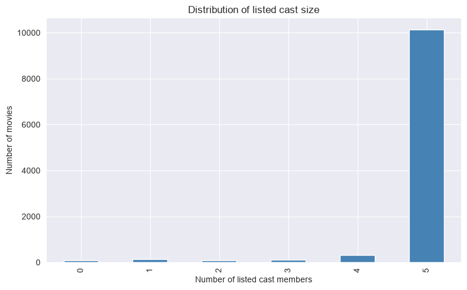

```python
# 1d: visualize the distribution of listed cast size.
cast_counts = df_clean['cast_count'].value_counts().sort_index()

ax = cast_counts.plot(kind='bar', figsize=(8, 5), color='steelblue')
style_axes(ax, 'Distribution of listed cast size',
           'Number of listed cast members', 'Number of movies')
plt.tight_layout()
plt.show()
```

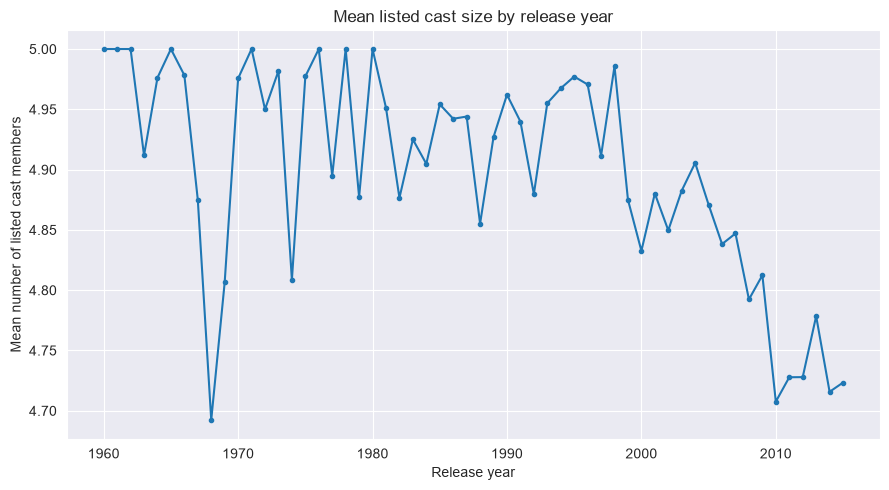

```python
# 2d over time: how has the mean listed cast size changed across release years?
mean_cast_by_year = df_clean.groupby('release_year')['cast_count'].mean()

ax = mean_cast_by_year.plot(kind='line', figsize=(9, 5), marker='.')
style_axes(ax, 'Mean listed cast size by release year',
           'Release year', 'Mean number of listed cast members')
plt.tight_layout()
plt.show()
```

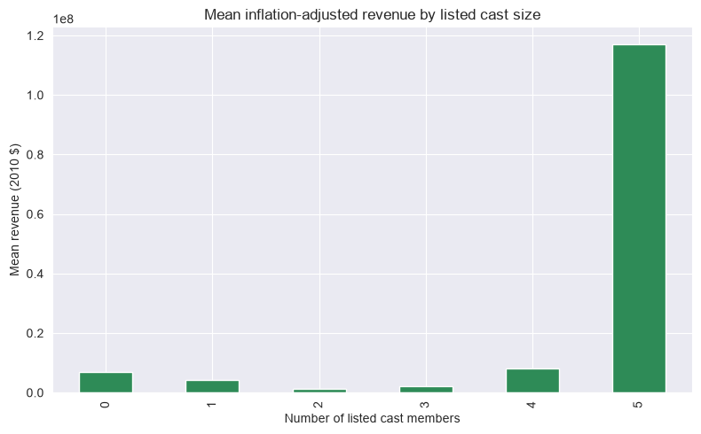

```
Correlation (cast_count vs revenue_adj): 0.060
```

```python
# 2d: relationship between listed cast size and inflation-adjusted revenue.
mean_revenue_by_cast = df_clean.groupby('cast_count')['revenue_adj'].mean()

ax = mean_revenue_by_cast.plot(kind='bar', figsize=(8, 5), color='seagreen')
style_axes(ax, 'Mean inflation-adjusted revenue by listed cast size',
           'Number of listed cast members', 'Mean revenue (2010 $)')
plt.tight_layout()
plt.show()

# Correlation between cast size and revenue (movies with a known revenue).
corr = df_clean[['cast_count', 'revenue_adj']].dropna().corr().iloc[0, 1]
print(f'Correlation (cast_count vs revenue_adj): {corr:.3f}')
```

```python
# Is the downward time trend real, or just a cataloguing artifact?
# Compare movie volume and how completely casts are listed across eras.
era = df_clean.groupby('release_year')
completeness = pd.DataFrame({
    'n_movies': era.size(),
    'mean_cast': era['cast_count'].mean().round(2),
    'pct_listing_under_5': (era['cast_count'].apply(lambda s: (s < 5).mean()) * 100).round(1),
})

print('Movies in dataset  —  1960s:', int(df_clean[df_clean['release_year'] < 1970].shape[0]),
      '|  2011-2015:', int(df_clean[df_clean['release_year'] >= 2011].shape[0]))
completeness.loc[[1960, 1980, 2000, 2010, 2015]]
```

```
Movies in dataset  —  1960s: 362 |  2011-2015: 3116
```

| release_year | n_movies | mean_cast | pct_listing_under_5 |
| --- | --- | --- | --- |
| 1960 | 32 | 5.00 | 0.0 |
| 1980 | 78 | 5.00 | 0.0 |
| 2000 | 227 | 4.83 | 7.9 |
| 2010 | 489 | 4.71 | 12.3 |
| 2015 | 629 | 4.72 | 10.7 |

**Findings — Research Question 1**

- **Distribution (1d):** Listed cast size is heavily concentrated at the maximum of 5 (10,133 of 10,865 movies, ~93%). Only 656 movies list 1–4 names and 76 list none, giving a mean of **4.84** and a median of **5**. The 76 movies that list *no* cast are overwhelmingly documentaries (42) and animation (30) — genres where a fictional cast is often absent or simply not entered, so the `0` reflects a real characteristic of those films rather than data to be "fixed".
- **Over time (2d):** The mean listed cast size does **not** rise over the years; if anything it drifts slightly **down**, from ~5.0 in the earliest years to ~4.7 by 2010–2015. The completeness table above shows this is an **artifact of cataloguing, not a real trend**: the number of movies in the dataset explodes from ~362 across the *entire* 1960s to ~3,116 in 2011–2015, while the share of titles listing *fewer than 5* names climbs from ≈0% (virtually every older film lists a full 5) to ~11% in recent years. Recent years sweep in a long tail of small/obscure titles whose casts are only partially entered, dragging the mean down — this is not a change in how many actors films actually employ.
- **Vs. revenue (2d):** Movies that list a full cast of 5 have a far higher *mean* inflation-adjusted revenue (~117M USD) than those listing fewer names (≤ 8M USD), yet the overall correlation between `cast_count` and `revenue_adj` is essentially zero (**r ≈ 0.06**). The gap is therefore driven by *catalogue completeness* — popular, high-grossing films get fully listed — not by cast size itself.

**Limitation:** because `cast` is capped at five names, `cast_count` measures listing completeness rather than true ensemble size, so it cannot tell us whether bigger real casts relate to success. We should not read the revenue gap as cast size *causing* higher revenue.

### Research Question 2: Small-cast vs full-cast performance

RQ1 suggested that listed cast size is largely a measure of **cataloguing completeness** rather than true ensemble size. Here we test that idea directly by grouping movies by listed cast size and comparing how each group performs on three success measures: **revenue** (`revenue_adj`), **rating** (`vote_average`), and **popularity** (`popularity`).

- **1d:** how many movies fall into each cast-size group.
- **2d:** how revenue and rating differ *across* those groups.

We bucket movies into **0 (none)**, **1–3 (small)**, **4**, and **5 (full)** listed cast members, and also track `vote_count` and how often revenue is even recorded — so we can tell genuine performance apart from the obscurity/cataloguing artifact.

```python
# Group movies by listed cast size so we can compare 'small' vs 'full' casts.
def label_cast_group(count):
    """Bucket a listed-cast count into an ordered, human-readable group."""
    if count == 0:
        return '0 (none)'
    if count <= 3:
        return '1-3 (small)'
    if count == 4:
        return '4'
    return '5 (full)'


group_order = ['0 (none)', '1-3 (small)', '4', '5 (full)']
df_clean['cast_size_group'] = pd.Categorical(
    df_clean['cast_count'].apply(label_cast_group),
    categories=group_order, ordered=True)

# Compare the success measures across groups. Revenue is highly skewed, so we use the
# median; we also track vote_count and how often revenue is even recorded, to expose
# whether differences reflect performance or simply catalogue completeness.
group_summary = df_clean.groupby('cast_size_group', observed=True).agg(
    n=('id', 'size'),
    median_revenue_adj=('revenue_adj', 'median'),
    mean_vote_average=('vote_average', 'mean'),
    mean_popularity=('popularity', 'mean'),
    median_vote_count=('vote_count', 'median'),
    pct_revenue_known=('revenue_adj', lambda x: x.notna().mean() * 100),
).round(2)
group_summary
```

| cast_size_group | n | median_revenue_adj | mean_vote_average | mean_popularity | median_vote_count | pct_revenue_known |
| --- | --- | --- | --- | --- | --- | --- |
| 0 (none) | 76 | 1086501.72 | 6.88 | 0.15 | 18.5 | 6.58 |
| 1-3 (small) | 343 | 804853.96 | 6.66 | 0.22 | 16.0 | 8.45 |
| 4 | 313 | 2147488.82 | 5.96 | 0.25 | 17.0 | 15.65 |
| 5 (full) | 10133 | 45566982.52 | 5.95 | 0.68 | 42.0 | 47.03 |

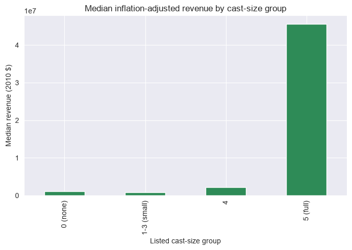

```python
# 2d: median inflation-adjusted revenue by cast-size group (movies with known revenue).
median_rev_by_group = df_clean.groupby('cast_size_group', observed=True)['revenue_adj'].median()

ax = median_rev_by_group.plot(kind='bar', figsize=(7, 5), color='seagreen')
style_axes(ax, 'Median inflation-adjusted revenue by cast-size group',
           'Listed cast-size group', 'Median revenue (2010 $)')
plt.tight_layout()
plt.show()
```

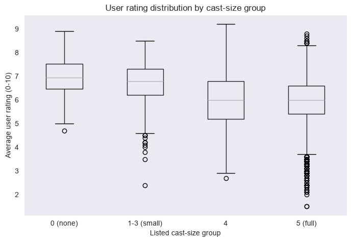

```python
# 2d: distribution of user ratings by cast-size group (a different angle than revenue).
ax = df_clean.boxplot(column='vote_average', by='cast_size_group', figsize=(7, 5),
                      grid=False)
style_axes(ax, 'User rating distribution by cast-size group',
           'Listed cast-size group', 'Average user rating (0-10)')
plt.suptitle('')  # remove the automatic 'Boxplot grouped by ...' title
plt.tight_layout()
plt.show()
```

**Findings — Research Question 2**

Comparing movies by listed cast-size group (the table and plots above):

- **Commercially, full-cast movies dominate.** Movies listing all 5 names have a median inflation-adjusted revenue of ~45.6M USD, versus only ~0.8M–2.1M USD for the small (1–3) and partial (4) groups — a 20–50× gap. They are also ~3× more *popular* (mean popularity 0.68 vs ~0.2) and attract far more votes (median 42 vs ~16).
- **But this is largely the same cataloguing artifact seen in RQ1.** Revenue is even *recorded* for only 7–16% of small/partial-cast movies, versus 47% of full-cast movies. Small-cast titles are overwhelmingly obscure films that were never fully catalogued, so the commercial "gap" mostly reflects which movies are well documented — not a causal effect of cast size.
- **On ratings the pattern slightly flips.** Small-cast (1–3) and no-cast movies have a *higher* mean `vote_average` (~6.7–6.9) than full-cast movies (~6.0). However, those ratings rest on very few votes (median ~16 vs 42), so they are noisier and likely reflect a small, self-selecting fan audience rather than broad acclaim.

**Limitation:** as in RQ1, `cast` is capped at five names, so cast-size group is a proxy for *cataloguing completeness / obscurity*, not true ensemble size. The revenue comparison also excludes the majority of small-cast movies (no revenue recorded), and the rating comparison rests on sharply unequal vote counts. These differences should not be read as cast size *causing* commercial or critical success.

### Research Question 3: Veteran stars and success

Do movies featuring a **prolific/veteran actor** earn more or score higher? We measure an actor's seniority by **how many films they appear in within this dataset**, flag each movie for whether it lists at least one such actor, and compare the groups — while keeping an eye on **`budget_adj`**, since star actors tend to be cast in bigger-budget films.

- **1d:** the distribution of how many films actors appear in (to choose a "veteran" cutoff).
- **2d:** revenue and rating for movies *with* vs *without* a veteran actor, and — to test for a budget confound — median revenue within budget quartiles.

```python
# Count how many films each actor appears in across the whole dataset (reusable helper).
actor_film_counts = pipe_value_counts(df_clean['cast'])

# Define 'veteran/prolific' actors as those appearing in >= 20 films (top ~2% of actors).
VETERAN_MIN_FILMS = 20
veteran_actors = set(actor_film_counts[actor_film_counts >= VETERAN_MIN_FILMS].index)
print(f'{len(actor_film_counts)} distinct actors; '
      f'{len(veteran_actors)} are "veteran" (>= {VETERAN_MIN_FILMS} films).')

# Flag movies that list at least one veteran actor.
df_clean['has_veteran'] = df_clean['cast'].fillna('').apply(
    lambda s: any(a in veteran_actors for a in s.split('|') if a))

# Compare success measures for movies with vs without a veteran actor.
veteran_summary = df_clean.groupby('has_veteran').agg(
    n=('id', 'size'),
    median_revenue_adj=('revenue_adj', 'median'),
    mean_vote_average=('vote_average', 'mean'),
    median_budget_adj=('budget_adj', 'median'),
    median_vote_count=('vote_count', 'median'),
    pct_revenue_known=('revenue_adj', lambda x: x.notna().mean() * 100),
).round(2)
veteran_summary
```

```
19026 distinct actors; 379 are "veteran" (>= 20 films).
```

| has_veteran | n | median_revenue_adj | mean_vote_average | median_budget_adj | median_vote_count | pct_revenue_known |
| --- | --- | --- | --- | --- | --- | --- |
| False | 5030 | 21102567.79 | 5.90 | 8297509.60 | 23.0 | 26.8 |
| True | 5835 | 57764880.35 | 6.04 | 31050611.23 | 74.0 | 60.0 |

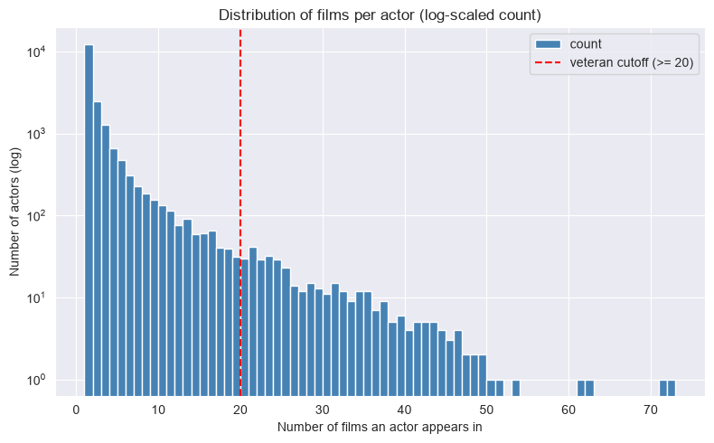

```python
# 1d: how many films do actors appear in? Most appear just once; a few are prolific.
ax = actor_film_counts.plot(kind='hist',
                            bins=range(1, int(actor_film_counts.max()) + 2),
                            figsize=(8, 5), color='steelblue', log=True)
style_axes(ax, 'Distribution of films per actor (log-scaled count)',
           'Number of films an actor appears in', 'Number of actors (log)')
ax.axvline(VETERAN_MIN_FILMS, color='red', linestyle='--',
           label=f'veteran cutoff (>= {VETERAN_MIN_FILMS})')
ax.legend()
plt.tight_layout()
plt.show()
```

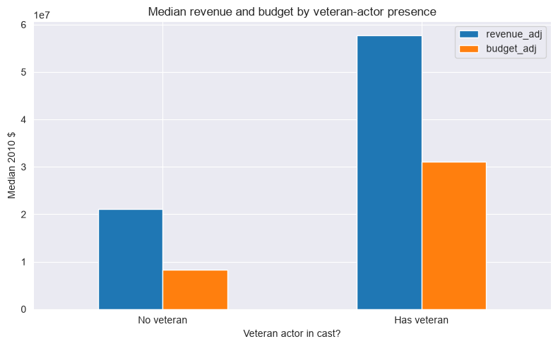

```python
# 2d: veteran movies earn far more on average -- but they also have far bigger budgets.
money_by_veteran = df_clean.groupby('has_veteran')[['revenue_adj', 'budget_adj']].median()
money_by_veteran.index = ['No veteran', 'Has veteran']

ax = money_by_veteran.plot(kind='bar', figsize=(8, 5))
style_axes(ax, 'Median revenue and budget by veteran-actor presence',
           'Veteran actor in cast?', 'Median 2010 $')
plt.xticks(rotation=0)
plt.tight_layout()
plt.show()
```

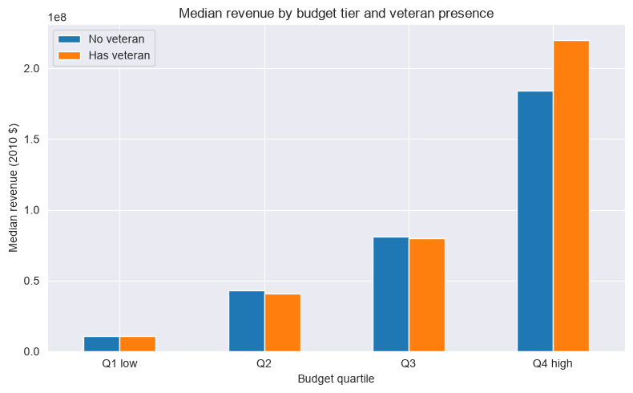

```python
# 2d: does the revenue gap survive once we control for budget?
# Split movies with known budget & revenue into budget quartiles, then compare medians.
paired = df_clean.dropna(subset=['budget_adj', 'revenue_adj']).copy()
paired['budget_tier'] = pd.qcut(paired['budget_adj'], 4,
                                labels=['Q1 low', 'Q2', 'Q3', 'Q4 high'])
rev_by_tier = (paired.groupby(['budget_tier', 'has_veteran'], observed=True)['revenue_adj']
               .median().unstack())
rev_by_tier.columns = ['No veteran', 'Has veteran']

ax = rev_by_tier.plot(kind='bar', figsize=(8, 5))
style_axes(ax, 'Median revenue by budget tier and veteran presence',
           'Budget quartile', 'Median revenue (2010 $)')
plt.xticks(rotation=0)
plt.tight_layout()
plt.show()
```

**Findings — Research Question 3**

Defining a **veteran/prolific actor** as one appearing in **≥ 20 films** in this dataset (379 of 19,026 actors — the top ~2%), about **54%** of movies list at least one.

- **Headline gap:** movies with a veteran actor have ~2.7× the median inflation-adjusted revenue (~57.8M vs ~21.1M USD) and a slightly higher mean rating (6.04 vs 5.90). They also draw far more votes (median 74 vs 23).
- **…but budget explains almost all of it.** Veteran movies also carry ~3.7× the median budget (~31M vs ~8.3M USD). When movies are split into budget quartiles, the revenue gap essentially **disappears** — within each tier the medians are nearly identical (e.g. Q3 ≈ 80M USD for both groups), with veteran films leading only in the top budget quartile. Veteran actors are mostly cast in bigger-budget productions, and it is the *budget* that tracks revenue, not star seniority itself.
- **Ratings barely move:** mean `vote_average` differs by only ~0.14 points, so a veteran presence is not associated with meaningfully better reviews.

**Limitation:** "veteran" here is a within-dataset film count — a rough proxy for an actor's true career experience or stature (the dataset is only a sample, the `cast` list is capped at five names, and a prolific bit-part actor counts the same as a lead). Because veteran presence is strongly confounded with budget, the raw revenue gap must **not** be read as veteran actors *causing* higher revenue.

### Research Question 4: The genre landscape

Which genres are associated with **higher ratings** versus **higher revenue**, and where does a niche illness theme — "dementia / Alzheimer" stories — sit within that landscape? Because `genres` is pipe-separated, we explode it so each movie counts toward every genre it lists, then summarise rating and revenue per genre.

- **1d:** how common each genre is.
- **2d:** each genre placed by mean rating vs median revenue (the "landscape"), with the dementia-themed subset overlaid to see where it falls.

```python
# Explode the pipe-separated genres so each movie contributes to every genre it lists.
genre_rows = df_clean.assign(genre=df_clean['genres'].fillna('').str.split('|')).explode('genre')
genre_rows = genre_rows[genre_rows['genre'].str.strip() != '']

# Per-genre 'landscape': how well-rated and how commercially successful each genre is.
genre_stats = genre_rows.groupby('genre').agg(
    n=('id', 'size'),
    mean_vote=('vote_average', 'mean'),
    median_revenue_adj=('revenue_adj', 'median'),
).round(2).sort_values('mean_vote', ascending=False)
genre_stats
```

| genre | n | mean_vote | median_revenue_adj |
| --- | --- | --- | --- |
| Documentary | 520 | 6.91 | 1.403939e+06 |
| Music | 408 | 6.48 | 3.407161e+07 |
| History | 334 | 6.41 | 6.151774e+07 |
| Animation | 699 | 6.40 | 1.485790e+08 |
| War | 270 | 6.30 | 7.128227e+07 |
| Drama | 4760 | 6.17 | 3.235333e+07 |
| Crime | 1354 | 6.12 | 4.898510e+07 |
| Western | 165 | 6.08 | 4.262895e+07 |
| Romance | 1712 | 6.04 | 3.657520e+07 |
| Family | 1231 | 6.00 | 1.017283e+08 |
| Foreign | 188 | 5.98 | 5.000000e+06 |
| Mystery | 810 | 5.95 | 4.185224e+07 |
| Adventure | 1471 | 5.94 | 1.150870e+08 |
| Comedy | 3793 | 5.91 | 4.671917e+07 |
| Fantasy | 916 | 5.86 | 1.013560e+08 |
| Action | 2384 | 5.79 | 7.616705e+07 |
| TV Movie | 167 | 5.79 | 5.838910e+07 |
| Thriller | 2907 | 5.75 | 4.445660e+07 |
| Science Fiction | 1229 | 5.67 | 7.095962e+07 |
| Horror | 1637 | 5.34 | 3.207359e+07 |

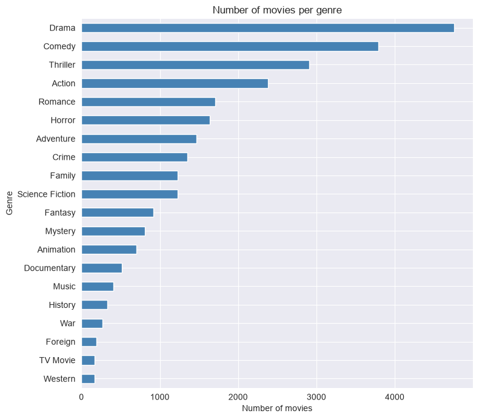

```python
# 1d: how common is each genre? (a movie can belong to several genres)
genre_counts = pipe_value_counts(df_clean['genres']).sort_values()

ax = genre_counts.plot(kind='barh', figsize=(8, 7), color='steelblue')
style_axes(ax, 'Number of movies per genre', 'Number of movies', 'Genre')
plt.tight_layout()
plt.show()
```

```python
# Locate the niche 'dementia / Alzheimer' illness theme via keyword + overview text.
text = df_clean['keywords'].fillna('') + ' ' + df_clean['overview'].fillna('')
dementia = df_clean[text.str.contains('dementia|alzheimer', case=False)]

dementia_point = (dementia['vote_average'].mean(), dementia['revenue_adj'].median())
overall_vote = df_clean['vote_average'].mean()
overall_rev = df_clean['revenue_adj'].median()
print(f'{len(dementia)} dementia/Alzheimer-themed movies')
print(f'  mean rating    : {dementia_point[0]:.2f}   (all movies: {overall_vote:.2f})')
print(f'  median revenue : {dementia_point[1]:,.0f}   (all movies: {overall_rev:,.0f})')
print('  most common genres:', ', '.join(pipe_value_counts(dementia['genres']).head(3).index))
```

```
18 dementia/Alzheimer-themed movies
  mean rating    : 6.49   (all movies: 5.98)
  median revenue : 23,555,590   (all movies: 43,956,661)
  most common genres: Drama, Thriller, Action
```

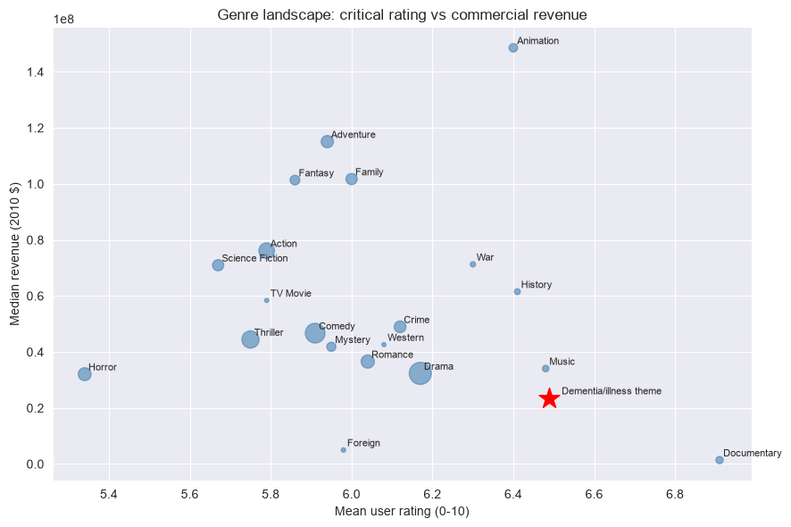

```python
# 2d: the genre 'landscape' -- mean rating (x) vs median revenue (y), one point per genre.
ax = genre_stats.plot.scatter(x='mean_vote', y='median_revenue_adj',
                              s=genre_stats['n'] / 15, figsize=(9, 6),
                              color='steelblue', alpha=0.6)
for genre, row in genre_stats.iterrows():
    ax.annotate(genre, (row['mean_vote'], row['median_revenue_adj']),
                fontsize=8, xytext=(3, 3), textcoords='offset points')

# Overlay where the niche dementia/illness theme sits, labelled in the same style
# as the genres (no legend needed for a single highlighted point).
ax.scatter(*dementia_point, color='red', marker='*', s=300, zorder=5)
ax.annotate('Dementia/illness theme', dementia_point,
            fontsize=8, xytext=(10, 3), textcoords='offset points')
style_axes(ax, 'Genre landscape: critical rating vs commercial revenue',
           'Mean user rating (0-10)', 'Median revenue (2010 $)')
plt.tight_layout()
plt.show()
```

**Findings — Research Question 4**

**Limitation:** genres overlap (each movie can list several), so the genre groups are not independent. Revenue medians rest only on movies whose revenue is recorded, and the dementia subset is **tiny (n = 18)** and identified by a crude keyword search — it is descriptive only, far too small for any statistical inference.

## ⭐ Standout: The dramatic arc of the 18 dementia-themed films

> The RQ4 probe surfaced **18 films that touch on dementia / Alzheimer's**. As a creative add-on, this section examines each film's *overarching dramatic arc* against a classic storytelling template:

> > *"In his efforts to reach a meaningful goal, a sympathetic protagonist, largely by his own effort, overcomes almost insurmountable odds and while doing so learns a valuable lesson."*

> For every film we record **two versions** of the story:
> - **`real_story`** — the plot's dramatic arc as it is publicly known.
> - **`template_story`** — that same arc rewritten to follow the template above.

> A short **`deviation`** note flags films whose true arc resists the template — for example tragedies of loss (*Iris*, *Away from Her*) where there is no triumph, or a creature-feature (*Deep Blue Sea*) where the "lesson" is really a punishment. Keeping both versions side by side lets us see *how well each film actually fits the heroic template* — the basis for the visualization we'll design next.

```python
# ---------------------------------------------------------------------------
# STANDOUT: dramatic-arc analysis of the 18 dementia/Alzheimer's-themed films
# ---------------------------------------------------------------------------
# For each film we store TWO versions of its story:
#   real_story     - the plot's overarching dramatic arc as it is known publicly
#   template_story - that same arc rewritten against the classic template:
#       "In his efforts to reach a meaningful goal, a sympathetic protagonist,
#        largely by his own effort, overcomes almost insurmountable odds and
#        while doing so learns a valuable lesson."
# Notes flag films whose arc deviates from the template (e.g. tragedies of loss
# where there is no triumph, or creature-features where the 'lesson' is a
# punishment) so the rewrite is not forced to imply success that isn't there.

story_arcs = [
    {
        "title": "Remember", "year": 2015,
        "real_story": "An elderly Auschwitz survivor with progressive dementia follows a friend's written instructions across America to track down and kill the Nazi guard who murdered their families - only to discover, when memory finally returns, that he himself is the man he hunted.",
        "template_story": "In his effort to avenge his murdered family, a sympathetic protagonist (Zev, a dementia-stricken survivor) battles his own collapsing memory to complete the quest, and while doing so learns the devastating lesson that he is the guilty man he sought.",
        "deviation": "Dark inversion: the 'valuable lesson' is a horrifying self-revelation, not a reward.",
    },
    {
        "title": "The Taking of Deborah Logan", "year": 2014,
        "real_story": "A film crew documenting an elderly woman's Alzheimer's decline uncovers that her terrifying symptoms mask a demonic possession, and her daughter must fight to save her.",
        "template_story": "In her effort to save her mother, a sympathetic protagonist (Sarah, the caregiver daughter) confronts an almost insurmountable supernatural evil hidden behind her mother's dementia, and learns how far love will go to reclaim a vanishing parent.",
        "deviation": "Fits loosely; horror framing rather than self-driven triumph.",
    },
    {
        "title": "Alive Inside", "year": 2014,
        "real_story": "A documentary following social worker Dan Cohen, whose simple idea - giving nursing-home dementia patients personalized music - reawakens memory and joy against an indifferent medical system.",
        "template_story": "In his effort to ease the suffering of fading dementia patients, a sympathetic protagonist (Dan Cohen) overcomes institutional resistance largely by his own initiative, and shows that music can revive a lost self.",
        "deviation": "Strong fit (documentary).",
    },
    {
        "title": "Deep Blue Sea", "year": 1999,
        "real_story": "Scientists genetically enlarge sharks' brains to harvest a cure for Alzheimer's, but the now-intelligent sharks turn on them, and the survivors must escape a flooding undersea lab.",
        "template_story": "In her effort to cure Alzheimer's, a protagonist (Dr. McAlester) unleashes almost insurmountable odds of her own making, and learns - too late - the deadly cost of overreaching nature.",
        "deviation": "Poor fit: a creature-feature where the 'lesson' arrives as punishment, not earned triumph.",
    },
    {
        "title": "Iris", "year": 2001,
        "real_story": "The true story of novelist Iris Murdoch and her husband John Bayley, charting their lifelong love as Alzheimer's erases the brilliant mind he adores.",
        "template_story": "In his effort to keep loving his wife as her mind disappears, a sympathetic protagonist (John Bayley) faces the insurmountable odds of an incurable disease, and learns that devotion endures even when memory cannot.",
        "deviation": "Inverted: no goal achieved; the arc is acceptance of loss, not victory.",
    },
    {
        "title": "Be Kind Rewind", "year": 2008,
        "real_story": "After a man accidentally erases every tape in a struggling video store, he and a friend reshoot the movies themselves, and their homemade versions unite the neighborhood.",
        "template_story": "In their effort to save a beloved failing video store, sympathetic protagonists (Mike and Jerry) overcome ruin and legal threats largely through their own ingenuity, and learn that a community's shared stories matter more than the originals.",
        "deviation": "Good fit, ensemble underdog arc.",
    },
    {
        "title": "Choke", "year": 2008,
        "real_story": "A sex-addicted con man who funds his institutionalized, dementia-ridden mother's care by faking restaurant choking incidents searches for the truth of his origins and a shot at real intimacy.",
        "template_story": "In his effort to care for his failing mother and uncover who he really is, a sympathetic protagonist (Victor) struggles against his own addictions and self-loathing, and learns that healing comes from honest connection rather than deception.",
        "deviation": "Fits, though the protagonist is an anti-hero.",
    },
    {
        "title": "Rise of the Planet of the Apes", "year": 2011,
        "real_story": "A scientist's experimental Alzheimer's drug grants his chimpanzee Caesar human-level intelligence; mistreated and caged, Caesar leads an ape revolt for freedom.",
        "template_story": "In his effort to win freedom and dignity for his kind, a sympathetic protagonist (Caesar) rises against captivity largely by his own will, and learns the power - and cost - of leadership.",
        "deviation": "Strong fit, but the protagonist is non-human.",
    },
    {
        "title": "How to Kill Your Neighbor's Dog", "year": 2002,
        "real_story": "A bitter, blocked playwright in a creative and marital slump unexpectedly finds renewal through a friendship with a young disabled girl next door.",
        "template_story": "In his effort to escape failure and reconnect with life, a sympathetic protagonist (Peter McGowan) overcomes his own cynicism and creative paralysis, and learns that purpose returns through unexpected human bonds.",
        "deviation": "Good fit (internal, character-driven arc).",
    },
    {
        "title": "Lockout", "year": 2012,
        "real_story": "A wrongly convicted ex-agent earns his freedom by infiltrating a riot-torn orbital prison to rescue the President's daughter.",
        "template_story": "In his effort to win back his freedom, a sympathetic protagonist (Snow) single-handedly overcomes a prison overrun by violent convicts, and learns to fight for something beyond himself.",
        "deviation": "Fits the action template; dementia link is incidental.",
    },
    {
        "title": "Imaginaerum", "year": 2012,
        "real_story": "An elderly composer lost to dementia journeys through the surreal landscape of his own childhood imagination to recover the memory of his estranged daughter before he dies.",
        "template_story": "In his effort to reclaim the love of his estranged daughter, a sympathetic protagonist (Tom) ventures through the maze of his failing mind, and learns that memory and reconciliation can be found even at the edge of oblivion.",
        "deviation": "Bittersweet fit; goal is reconciliation, not survival.",
    },
    {
        "title": "De Zaak Alzheimer", "year": 2003,
        "real_story": "An aging contract killer in the grip of early Alzheimer's refuses to murder a child, then turns his fading skills against the corrupt men who hired him.",
        "template_story": "In his effort to atone before his memory is gone, a sympathetic protagonist (Angelo Ledda, the dying assassin) battles both his employers and his own disintegrating mind, and learns that even a killer can choose conscience.",
        "deviation": "Fits as a redemption arc with a doomed protagonist.",
    },
    {
        "title": "Harvie Krumpet", "year": 2003,
        "real_story": "A clay-animated life story of a perpetually unlucky man - born with Tourette's, later struck by lightning and dementia - who nonetheless keeps finding love and meaning in life.",
        "template_story": "In his effort to live a good life despite relentless misfortune, a sympathetic protagonist (Harvie Krumpet) overcomes one insurmountable blow after another, and learns to seize life's fleeting joys.",
        "deviation": "Very strong thematic fit ('carpe diem').",
    },
    {
        "title": "Nebraska", "year": 2013,
        "real_story": "Convinced a junk-mail sweepstakes letter is real, a stubborn, declining old man drags his estranged son on a road trip to claim it, and the journey rebuilds their bond.",
        "template_story": "In his effort to claim a prize and a last shred of dignity, a sympathetic protagonist (Woody Grant) presses on against ridicule and his own decline, and - through his son's help - learns he is still loved.",
        "deviation": "Fits, though the 'prize' is an illusion; the real reward is reconciliation.",
    },
    {
        "title": "Proof", "year": 2005,
        "real_story": "A young woman who cared for her mentally failing mathematician father must prove she - not he - authored a landmark proof, while fearing she's inherited his madness.",
        "template_story": "In her effort to claim her own genius and sanity, a sympathetic protagonist (Catherine) overcomes grief and others' disbelief largely by her own resolve, and learns to trust herself.",
        "deviation": "Good fit (self-driven, earns the lesson).",
    },
    {
        "title": "Away from Her", "year": 2006,
        "real_story": "As his wife's Alzheimer's worsens and she transfers her affection to a fellow nursing-home patient, a devoted husband must learn to let her go for her own happiness.",
        "template_story": "In his effort to keep loving his wife, a sympathetic protagonist (Grant) faces the insurmountable odds of her vanishing self, and learns the hardest lesson - that love can mean letting go.",
        "deviation": "Inverted: selfless surrender, not triumph.",
    },
    {
        "title": "The Notebook", "year": 2004,
        "real_story": "An old man reads aloud to a woman with Alzheimer's the story of a young couple's passionate, separated love - revealed to be their own - hoping to reawaken her memory of him.",
        "template_story": "In his effort to reach his wife across the fog of Alzheimer's, a sympathetic protagonist (Noah/Duke) returns day after day against impossible odds, and learns that love can momentarily defeat even oblivion.",
        "deviation": "Fits, with only a fleeting, bittersweet victory.",
    },
    {
        "title": "Noel", "year": 2004,
        "real_story": "On a single Christmas Eve in New York, several lonely strangers - among them a publisher caring for her Alzheimer's-stricken mother - search for connection and small miracles.",
        "template_story": "In her effort to find hope amid loneliness and her mother's decline, a sympathetic protagonist (Rose) reaches out against despair, and learns that grace can arrive in unexpected company.",
        "deviation": "Loose fit: ensemble mood piece rather than a single goal-driven arc.",
    },
]

story_arcs_df = pd.DataFrame(story_arcs)
print(f"Stored {len(story_arcs_df)} films, each with a real_story and a template_story.")
with pd.option_context('display.max_colwidth', None):
    display(story_arcs_df[['title', 'year', 'real_story', 'template_story', 'deviation']])
```

```
Stored 18 films, each with a real_story and a template_story.
```

|  | title | year | real_story | template_story | deviation |
| --- | --- | --- | --- | --- | --- |
| 0 | Remember | 2015 | An elderly Auschwitz survivor with progressive dementia follows a friend's written instructions across America to track down and kill the Nazi guard who murdered their families - only to discover, whe… | In his effort to avenge his murdered family, a sympathetic protagonist (Zev, a dementia-stricken survivor) battles his own collapsing memory to complete the quest, and while doing so learns the devast… | Dark inversion: the 'valuable lesson' is a horrifying self-revelation, not a reward. |
| 1 | The Taking of Deborah Logan | 2014 | A film crew documenting an elderly woman's Alzheimer's decline uncovers that her terrifying symptoms mask a demonic possession, and her daughter must fight to save her. | In her effort to save her mother, a sympathetic protagonist (Sarah, the caregiver daughter) confronts an almost insurmountable supernatural evil hidden behind her mother's dementia, and learns how far… | Fits loosely; horror framing rather than self-driven triumph. |
| 2 | Alive Inside | 2014 | A documentary following social worker Dan Cohen, whose simple idea - giving nursing-home dementia patients personalized music - reawakens memory and joy against an indifferent medical system. | In his effort to ease the suffering of fading dementia patients, a sympathetic protagonist (Dan Cohen) overcomes institutional resistance largely by his own initiative, and shows that music can revive… | Strong fit (documentary). |
| 3 | Deep Blue Sea | 1999 | Scientists genetically enlarge sharks' brains to harvest a cure for Alzheimer's, but the now-intelligent sharks turn on them, and the survivors must escape a flooding undersea lab. | In her effort to cure Alzheimer's, a protagonist (Dr. McAlester) unleashes almost insurmountable odds of her own making, and learns - too late - the deadly cost of overreaching nature. | Poor fit: a creature-feature where the 'lesson' arrives as punishment, not earned triumph. |
| 4 | Iris | 2001 | The true story of novelist Iris Murdoch and her husband John Bayley, charting their lifelong love as Alzheimer's erases the brilliant mind he adores. | In his effort to keep loving his wife as her mind disappears, a sympathetic protagonist (John Bayley) faces the insurmountable odds of an incurable disease, and learns that devotion endures even when … | Inverted: no goal achieved; the arc is acceptance of loss, not victory. |
| 5 | Be Kind Rewind | 2008 | After a man accidentally erases every tape in a struggling video store, he and a friend reshoot the movies themselves, and their homemade versions unite the neighborhood. | In their effort to save a beloved failing video store, sympathetic protagonists (Mike and Jerry) overcome ruin and legal threats largely through their own ingenuity, and learn that a community's share… | Good fit, ensemble underdog arc. |
| 6 | Choke | 2008 | A sex-addicted con man who funds his institutionalized, dementia-ridden mother's care by faking restaurant choking incidents searches for the truth of his origins and a shot at real intimacy. | In his effort to care for his failing mother and uncover who he really is, a sympathetic protagonist (Victor) struggles against his own addictions and self-loathing, and learns that healing comes from… | Fits, though the protagonist is an anti-hero. |
| 7 | Rise of the Planet of the Apes | 2011 | A scientist's experimental Alzheimer's drug grants his chimpanzee Caesar human-level intelligence; mistreated and caged, Caesar leads an ape revolt for freedom. | In his effort to win freedom and dignity for his kind, a sympathetic protagonist (Caesar) rises against captivity largely by his own will, and learns the power - and cost - of leadership. | Strong fit, but the protagonist is non-human. |
| 8 | How to Kill Your Neighbor's Dog | 2002 | A bitter, blocked playwright in a creative and marital slump unexpectedly finds renewal through a friendship with a young disabled girl next door. | In his effort to escape failure and reconnect with life, a sympathetic protagonist (Peter McGowan) overcomes his own cynicism and creative paralysis, and learns that purpose returns through unexpected… | Good fit (internal, character-driven arc). |
| 9 | Lockout | 2012 | A wrongly convicted ex-agent earns his freedom by infiltrating a riot-torn orbital prison to rescue the President's daughter. | In his effort to win back his freedom, a sympathetic protagonist (Snow) single-handedly overcomes a prison overrun by violent convicts, and learns to fight for something beyond himself. | Fits the action template; dementia link is incidental. |
| 10 | Imaginaerum | 2012 | An elderly composer lost to dementia journeys through the surreal landscape of his own childhood imagination to recover the memory of his estranged daughter before he dies. | In his effort to reclaim the love of his estranged daughter, a sympathetic protagonist (Tom) ventures through the maze of his failing mind, and learns that memory and reconciliation can be found even … | Bittersweet fit; goal is reconciliation, not survival. |
| 11 | De Zaak Alzheimer | 2003 | An aging contract killer in the grip of early Alzheimer's refuses to murder a child, then turns his fading skills against the corrupt men who hired him. | In his effort to atone before his memory is gone, a sympathetic protagonist (Angelo Ledda, the dying assassin) battles both his employers and his own disintegrating mind, and learns that even a killer… | Fits as a redemption arc with a doomed protagonist. |
| 12 | Harvie Krumpet | 2003 | A clay-animated life story of a perpetually unlucky man - born with Tourette's, later struck by lightning and dementia - who nonetheless keeps finding love and meaning in life. | In his effort to live a good life despite relentless misfortune, a sympathetic protagonist (Harvie Krumpet) overcomes one insurmountable blow after another, and learns to seize life's fleeting joys. | Very strong thematic fit ('carpe diem'). |
| 13 | Nebraska | 2013 | Convinced a junk-mail sweepstakes letter is real, a stubborn, declining old man drags his estranged son on a road trip to claim it, and the journey rebuilds their bond. | In his effort to claim a prize and a last shred of dignity, a sympathetic protagonist (Woody Grant) presses on against ridicule and his own decline, and - through his son's help - learns he is still l… | Fits, though the 'prize' is an illusion; the real reward is reconciliation. |
| 14 | Proof | 2005 | A young woman who cared for her mentally failing mathematician father must prove she - not he - authored a landmark proof, while fearing she's inherited his madness. | In her effort to claim her own genius and sanity, a sympathetic protagonist (Catherine) overcomes grief and others' disbelief largely by her own resolve, and learns to trust herself. | Good fit (self-driven, earns the lesson). |
| 15 | Away from Her | 2006 | As his wife's Alzheimer's worsens and she transfers her affection to a fellow nursing-home patient, a devoted husband must learn to let her go for her own happiness. | In his effort to keep loving his wife, a sympathetic protagonist (Grant) faces the insurmountable odds of her vanishing self, and learns the hardest lesson - that love can mean letting go. | Inverted: selfless surrender, not triumph. |
| 16 | The Notebook | 2004 | An old man reads aloud to a woman with Alzheimer's the story of a young couple's passionate, separated love - revealed to be their own - hoping to reawaken her memory of him. | In his effort to reach his wife across the fog of Alzheimer's, a sympathetic protagonist (Noah/Duke) returns day after day against impossible odds, and learns that love can momentarily defeat even obl… | Fits, with only a fleeting, bittersweet victory. |
| 17 | Noel | 2004 | On a single Christmas Eve in New York, several lonely strangers - among them a publisher caring for her Alzheimer's-stricken mother - search for connection and small miracles. | In her effort to find hope amid loneliness and her mother's decline, a sympathetic protagonist (Rose) reaches out against despair, and learns that grace can arrive in unexpected company. | Loose fit: ensemble mood piece rather than a single goal-driven arc. |

#### Who carries the dementia?

The 18 films split by *which character* the disease belongs to. This turns out to track how well each film fits the heroic template: when the **protagonist** has dementia, the "by his own effort… learns a lesson" arc strains hardest; when a **caregiver** drives the story, the template fits more conventionally.

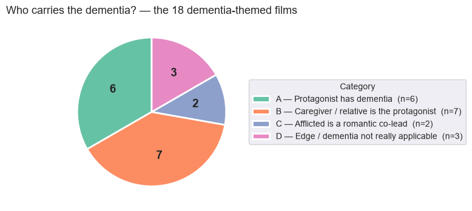

```python
# Categorize the 18 films by WHO carries the dementia, then visualize the split.
# Categories are derived from the story_arcs data, so the chart stays in sync with it.
arc_categories = {
    "A — Protagonist has dementia": [
        "Remember", "Iris", "Imaginaerum", "De Zaak Alzheimer",
        "Harvie Krumpet", "Nebraska",
    ],
    "B — Caregiver / relative is the protagonist": [
        "Alive Inside", "The Taking of Deborah Logan", "Be Kind Rewind",
        "Choke", "Rise of the Planet of the Apes", "Proof", "Noel",
    ],
    "C — Afflicted is a romantic co-lead": [
        "Away from Her", "The Notebook",
    ],
    "D — Edge / dementia not really applicable": [
        "Deep Blue Sea", "Lockout", "How to Kill Your Neighbor's Dog",
    ],
}

# Reusable lookup: film title -> category. Attach as a column on the DataFrame.
title_to_category = {t: cat for cat, titles in arc_categories.items() for t in titles}
story_arcs_df["category"] = story_arcs_df["title"].map(title_to_category)
assert story_arcs_df["category"].notna().all(), "Some films were not categorized"

category_counts = story_arcs_df["category"].value_counts().reindex(arc_categories.keys())

fig, ax = plt.subplots(figsize=(7, 7))
colors = sns.color_palette("Set2", len(category_counts))
wedges, _ = ax.pie(
    category_counts, colors=colors, startangle=90,
    wedgeprops=dict(edgecolor="white", linewidth=2),
)
# Print the count inside each wedge.
for wedge, count in zip(wedges, category_counts):
    angle = np.deg2rad((wedge.theta1 + wedge.theta2) / 2)
    ax.text(0.6 * np.cos(angle), 0.6 * np.sin(angle), str(count),
            ha="center", va="center", fontsize=14, fontweight="bold")
ax.set_aspect("equal")
ax.set_title("Who carries the dementia? — the 18 dementia-themed films", fontsize=13)
ax.legend(
    wedges,
    [f"{label}  (n={count})" for label, count in category_counts.items()],
    title="Category", loc="center left", bbox_to_anchor=(1.0, 0.5),
)
plt.tight_layout()
plt.show()
```

#### Group A in detail — when the hero is the one forgetting

For the six films where the **protagonist themselves has dementia**, the table below breaks each story into the template's four dramatic elements: the **goal** they pursue, the **odds** stacked against them, and the **lesson** they reach. Notice how often the disease *is* the central obstacle, and how several of the "lessons" are bittersweet or tragic rather than triumphant.

```python
# Detail table for the six Group-A films (the protagonist is the one with dementia),
# broken into the template's four dramatic elements: goal, odds, lesson.
group_a_details = {
    "Remember": {
        "protagonist": "Zev Guttman (elderly Auschwitz survivor)",
        "goal": "Avenge his murdered family by hunting down the Nazi guard responsible",
        "odds": "His own advancing dementia erasing the mission from his mind",
        "lesson": "The man he hunts is himself - a horrifying self-revelation",
    },
    "Iris": {
        "protagonist": "Iris Murdoch (acclaimed novelist)",
        "goal": "Hold on to her brilliant mind, her selfhood and her love",
        "odds": "Incurable, progressive Alzheimer's erasing her intellect",
        "lesson": "Love and devotion endure even when memory cannot",
    },
    "Imaginaerum": {
        "protagonist": "Tom (elderly composer)",
        "goal": "Recover the memory of his estranged daughter and reconcile before death",
        "odds": "Severe dementia regressing him to childhood as he drifts toward coma",
        "lesson": "Memory and reconciliation can be found even at the edge of oblivion",
    },
    "De Zaak Alzheimer": {
        "protagonist": "Angelo Ledda (aging contract killer)",
        "goal": "Atone - refuse to kill a child and bring down his corrupt employers",
        "odds": "Advancing Alzheimer's eroding his skills while he is hunted",
        "lesson": "Even a killer can choose conscience",
    },
    "Harvie Krumpet": {
        "protagonist": "Harvie Krumpet (luckless everyman)",
        "goal": "Live a good and meaningful life despite relentless misfortune",
        "odds": "A lifetime of bad luck - Tourette's, a lightning strike, then dementia",
        "lesson": "Seize life's fleeting joys (carpe diem)",
    },
    "Nebraska": {
        "protagonist": "Woody Grant (declining, stubborn father)",
        "goal": "Reach Nebraska to claim a sweepstakes prize and a last shred of dignity",
        "odds": "Ridicule, family doubt and his own cognitive decline",
        "lesson": "The prize is fake, but he is still loved",
    },
}

# Order the rows to match Group A in story_arcs_df, so the table stays in sync.
group_a_titles = story_arcs_df.loc[
    story_arcs_df["category"].str.startswith("A"), "title"
].tolist()

group_a_df = (
    pd.DataFrame.from_dict(group_a_details, orient="index")
      .reindex(group_a_titles)
      .reset_index()
      .rename(columns={"index": "movie"})
)

with pd.option_context('display.max_colwidth', None):
    display(group_a_df)
```

|  | movie | protagonist | goal | odds | lesson |
| --- | --- | --- | --- | --- | --- |
| 0 | Remember | Zev Guttman (elderly Auschwitz survivor) | Avenge his murdered family by hunting down the Nazi guard responsible | His own advancing dementia erasing the mission from his mind | The man he hunts is himself - a horrifying self-revelation |
| 1 | Iris | Iris Murdoch (acclaimed novelist) | Hold on to her brilliant mind, her selfhood and her love | Incurable, progressive Alzheimer's erasing her intellect | Love and devotion endure even when memory cannot |
| 2 | Imaginaerum | Tom (elderly composer) | Recover the memory of his estranged daughter and reconcile before death | Severe dementia regressing him to childhood as he drifts toward coma | Memory and reconciliation can be found even at the edge of oblivion |
| 3 | De Zaak Alzheimer | Angelo Ledda (aging contract killer) | Atone - refuse to kill a child and bring down his corrupt employers | Advancing Alzheimer's eroding his skills while he is hunted | Even a killer can choose conscience |
| 4 | Harvie Krumpet | Harvie Krumpet (luckless everyman) | Live a good and meaningful life despite relentless misfortune | A lifetime of bad luck - Tourette's, a lightning strike, then dementia | Seize life's fleeting joys (carpe diem) |
| 5 | Nebraska | Woody Grant (declining, stubborn father) | Reach Nebraska to claim a sweepstakes prize and a last shred of dignity | Ridicule, family doubt and his own cognitive decline | The prize is fake, but he is still loved |

## Conclusions

This project explored the TMDb movie dataset (10,865 movies after cleaning) to ask **what is associated with a movie's success**, where success was measured two ways: inflation-adjusted box-office revenue (`revenue_adj`) and audience rating (`vote_average`). Four questions were investigated.

**RQ1 — Does cast size relate to success, and has it changed over time?** The mean number of *listed* cast members drifted slightly **down** across release years (from ~5.0 in the earliest years to ~4.7 by 2010–2015), and revenue showed only a very weak positive correlation with cast size (Pearson *r* ≈ 0.06). A diagnostic by era revealed that this apparent "trend" is largely a **cataloguing artifact**: almost every older film lists a full five names, whereas the flood of small/obscure titles in recent years are only partially catalogued, so a growing share list fewer than five. The drift therefore reflects how completely TMDb records newer versus older films, not a real change in production. No meaningful link between cast size and revenue was found.

**RQ2 — Do small-cast movies perform differently from full-cast movies?** Grouping movies by cast size (none / 1–3 / 4 / 5-listed) showed that fully-listed movies have far higher median revenue, popularity and vote counts, while sparsely-listed movies sit at the bottom on those commercial measures (their *ratings* actually run a little **higher**, but on very few votes, so the difference is noisy). Given the RQ1 finding, this is best read as a **side-effect of cataloguing completeness** — well-documented (and typically bigger, more recent) films tend to be the ones with a full cast list — rather than evidence that adding cast members improves a movie.

**RQ3 — Are movies with veteran (frequently-cast) stars more successful?** Defining a "veteran" as an actor with ≥ 20 films in the dataset (379 actors), movies featuring at least one veteran had higher median revenue *and* higher median budget. After splitting by budget quartile, the veteran revenue advantage shrank substantially within each tier, indicating the headline gap is **largely confounded by budget**: veteran-led films tend to be bigger-budget productions. Veteran presence is associated with, but not a clear independent driver of, revenue.

### Limitations

- **No causal claims.** All results are correlational and descriptive; no statistical tests or models were run, so none of these associations should be read as causes of success.
- **Missing and zero-coded financials.** Budget and revenue were `0` for a large share of rows (treated as missing). Revenue-based comparisons therefore reflect only the subset of films with reported earnings, which skews toward larger studio releases and may bias the medians upward.
- **Cataloguing bias.** As RQ1/RQ2 showed, completeness of fields like `cast` varies systematically by era, which can manufacture apparent trends.
- **Overlapping, tiny subsets.** Genres overlap (a film counts in several), and thematic subsets like the dementia probe (*n* = 18) are far too small for inference.

### Further research

Stronger conclusions would require: controlled comparisons (e.g., regression holding budget, year and genre constant), a financially complete dataset, and proper statistical testing. Profit (revenue − budget) and return-on-budget would also be more meaningful success measures than raw revenue.

## Submitting the Project

The cell below converts this notebook to an `.html` file for submission.

```python
# Running this cell will execute a bash command to convert this notebook to an .html file
!python -m nbconvert --to html Investigate_a_Dataset.ipynb
```